# Shopping Cart Data Analysis

### Authors:

**Nur Inna Alfianinda**

### Description:

Explore e-commerce data using descriptive statistics, univariate, bivariate, multivariate analysis, and machine learning algorithm.

### Dataset: https://www.kaggle.com/knightbearr/analysis-shopping-cart-data-knightbearr

### Outline:

1. Data Extraction
2. Data Preparation
3. Exploratory Data Analysis
4. Sales Forecasting
5. Customer Segmentation
6. Answer to Business Problems and Business Recommendation

### Objective:

1. Prevent the decline in product sales (up to 25.32%) after the beginning of the Autumn and Winter seasons
2. Increase product sales by at least 28.78% in 2022.

## Import Libraries

```python
import pandas as pd
import numpy as np
from datetime import datetime
import matplotlib.pyplot as plt
import seaborn as sns
from scipy import stats
from scipy.stats import f_oneway
from scipy.stats import chi2_contingency

import warnings
warnings.filterwarnings("ignore")
```

```python
pd.set_option('display.max_columns', None)
```

## 1. Data Extraction

```python
sheet_url = 'https://docs.google.com/spreadsheets/d/1_8nyEqVfj_f8uRpsuPqO2wrmQqIwRtT2dTCArNXgtkA/edit#gid=1132623112'
sheet_url_trf = sheet_url.replace('/edit#gid=', '/export?format=csv&gid=')
df_read = pd.read_csv(sheet_url_trf)
df_read
```

|  | sales_id | order_id | product_id | price_per_unit | quantity | total_price | customer_id | payment | order_date | delivery_date | product_type | product_name | size | colour | price | quantity.1 | description | customer_name | gender | age | home_address | zip_code | city | state | country | min discount per product | profit per product | profit per product (dollar) | total profit (dollar) |
| --- | --- | --- | --- | --- | --- | --- | --- | --- | --- | --- | --- | --- | --- | --- | --- | --- | --- | --- | --- | --- | --- | --- | --- | --- | --- | --- | --- | --- | --- |
| 0 | 0 | 1 | 218 | 106 | 2 | 212 | 64 | 30811 | 30/08/2021 | 24/09/2021 | Shirt | Chambray | L | orange | 105 | 44 | A orange coloured, L sized, Chambray Shirt | Annabella Devote | Genderfluid | 75 | 4927 Alice MeadowApt. 960 | 7787 | Sanfordborough | South Australia | Australia | 0% | 0.95% | 1 | 2 |
| 1 | 1 | 1 | 481 | 118 | 1 | 118 | 64 | 30811 | 30/08/2021 | 24/09/2021 | Jacket | Puffer | S | indigo | 110 | 62 | A indigo coloured, S sized, Puffer Jacket | Annabella Devote | Genderfluid | 75 | 4927 Alice MeadowApt. 960 | 7787 | Sanfordborough | South Australia | Australia | 0% | 7.27% | 8 | 8 |
| 2 | 2 | 1 | 2 | 96 | 3 | 288 | 64 | 30811 | 30/08/2021 | 24/09/2021 | Shirt | Oxford Cloth | M | red | 114 | 54 | A red coloured, M sized, Oxford Cloth Shirt | Annabella Devote | Genderfluid | 75 | 4927 Alice MeadowApt. 960 | 7787 | Sanfordborough | South Australia | Australia | 15.79% | 0% | 0 | 0 |
| 3 | 3 | 1 | 1002 | 106 | 2 | 212 | 64 | 30811 | 30/08/2021 | 24/09/2021 | Trousers | Wool | M | blue | 111 | 52 | A blue coloured, M sized, Wool Trousers | Annabella Devote | Genderfluid | 75 | 4927 Alice MeadowApt. 960 | 7787 | Sanfordborough | South Australia | Australia | 4.5% | 0% | 0 | 0 |
| 4 | 4 | 1 | 691 | 113 | 3 | 339 | 64 | 30811 | 30/08/2021 | 24/09/2021 | Jacket | Parka | S | indigo | 119 | 53 | A indigo coloured, S sized, Parka Jacket | Annabella Devote | Genderfluid | 75 | 4927 Alice MeadowApt. 960 | 7787 | Sanfordborough | South Australia | Australia | 5.04% | 0% | 0 | 0 |
| ... | ... | ... | ... | ... | ... | ... | ... | ... | ... | ... | ... | ... | ... | ... | ... | ... | ... | ... | ... | ... | ... | ... | ... | ... | ... | ... | ... | ... | ... |
| 4995 | 4995 | 998 | 321 | 109 | 2 | 218 | 407 | 53308 | 05/05/2021 | 21/05/2021 | Shirt | Mandarin Collar | S | orange | 108 | 52 | A orange coloured, S sized, Mandarin Collar Shirt | Murdock Bulfit | Male | 41 | 5233 Lara AvenueSuite 291 | 8697 | Hartmannshire | Queensland | Australia | 0% | 0.93% | 1 | 2 |
| 4996 | 4996 | 998 | 251 | 95 | 3 | 285 | 407 | 53308 | 05/05/2021 | 21/05/2021 | Shirt | Polo | S | orange | 117 | 78 | A orange coloured, S sized, Polo Shirt | Murdock Bulfit | Male | 41 | 5233 Lara AvenueSuite 291 | 8697 | Hartmannshire | Queensland | Australia | 18.8% | 0% | 0 | 0 |
| 4997 | 4997 | 999 | 872 | 113 | 1 | 113 | 428 | 31643 | 15/06/2021 | 12/07/2021 | Trousers | Chinos | M | violet | 100 | 54 | A violet coloured, M sized, Chinos Trousers | Jammal Varcoe | Polygender | 66 | 80 Hermiston WaySuite 403 | 1112 | North Liamfort | Australian Capital Territory | Australia | 0% | 13% | 13 | 13 |
| 4998 | 4998 | 999 | 998 | 106 | 2 | 212 | 428 | 31643 | 15/06/2021 | 12/07/2021 | Trousers | Wool | L | green | 111 | 42 | A green coloured, L sized, Wool Trousers | Jammal Varcoe | Polygender | 66 | 80 Hermiston WaySuite 403 | 1112 | North Liamfort | Australian Capital Territory | Australia | 4.5% | 0% | 0 | 0 |
| 4999 | 4999 | 999 | 1105 | 115 | 1 | 115 | 428 | 31643 | 15/06/2021 | 12/07/2021 | Trousers | Cropped | XS | blue | 99 | 47 | A blue coloured, XS sized, Cropped Trousers | Jammal Varcoe | Polygender | 66 | 80 Hermiston WaySuite 403 | 1112 | North Liamfort | Australian Capital Territory | Australia | 0% | 16.16% | 16 | 16 |

5000 rows × 29 columns

```python
df = df_read.copy()
```

## 2. Data Cleaning

### 2.1 Understanding the Dataset

```python
df.info()
```

```
<class 'pandas.core.frame.DataFrame'>
RangeIndex: 5000 entries, 0 to 4999
Data columns (total 29 columns):
 #   Column                       Non-Null Count  Dtype
---  ------                       --------------  -----
 0   sales_id                     5000 non-null   int64
 1   order_id                     5000 non-null   int64
 2   product_id                   5000 non-null   int64
 3   price_per_unit               5000 non-null   int64
 4   quantity                     5000 non-null   int64
 5   total_price                  5000 non-null   int64
 6   customer_id                  5000 non-null   int64
 7   payment                      5000 non-null   int64
 8   order_date                   5000 non-null   object
 9   delivery_date                5000 non-null   object
```

[output cut: 21 more lines]

```python
m = df.shape[0]
n = df.shape[1]

print("Number of rows: " + str(m))
print("Number of columns: " + str(n))
```

```
Number of rows: 5000
Number of columns: 29
```

### 2.2 Data Cleaning

#### 2.2.1 Missing Values

```python
df.isna().sum()
```

```
sales_id                       0
order_id                       0
product_id                     0
price_per_unit                 0
quantity                       0
total_price                    0
customer_id                    0
payment                        0
order_date                     0
delivery_date                  0
product_type                   0
product_name                   0
size                           0
colour                         0
price                          0
quantity.1                     0
description                    0
customer_name                  0
gender                         0
age                            0
home_address                   0
zip_code                       0
city                           0
state                          0
country                        0
min discount per product       0
profit per product             0
profit per product (dollar)    0
total profit (dollar)          0
dtype: int64
```

*There are no missing values in all columns*

#### 2.2.2 Duplicated Data

```python
print("Number of duplicated data:", df.duplicated().sum())
```

```
Number of duplicated data: 0
```

#### 2.2.3 Convert Data Type

```python
df.dtypes
```

```
sales_id                        int64
order_id                        int64
product_id                      int64
price_per_unit                  int64
quantity                        int64
total_price                     int64
customer_id                     int64
payment                         int64
order_date                     object
delivery_date                  object
product_type                   object
product_name                   object
size                           object
colour                         object
price                           int64
quantity.1                      int64
description                    object
customer_name                  object
gender                         object
age                             int64
home_address                   object
zip_code                        int64
city                           object
state                          object
country                        object
min discount per product       object
profit per product             object
profit per product (dollar)     int64
total profit (dollar)           int64
dtype: object
```

```python
df.head(3)
```

|  | sales_id | order_id | product_id | price_per_unit | quantity | total_price | customer_id | payment | order_date | delivery_date | product_type | product_name | size | colour | price | quantity.1 | description | customer_name | gender | age | home_address | zip_code | city | state | country | min discount per product | profit per product | profit per product (dollar) | total profit (dollar) |
| --- | --- | --- | --- | --- | --- | --- | --- | --- | --- | --- | --- | --- | --- | --- | --- | --- | --- | --- | --- | --- | --- | --- | --- | --- | --- | --- | --- | --- | --- |
| 0 | 0 | 1 | 218 | 106 | 2 | 212 | 64 | 30811 | 30/08/2021 | 24/09/2021 | Shirt | Chambray | L | orange | 105 | 44 | A orange coloured, L sized, Chambray Shirt | Annabella Devote | Genderfluid | 75 | 4927 Alice MeadowApt. 960 | 7787 | Sanfordborough | South Australia | Australia | 0% | 0.95% | 1 | 2 |
| 1 | 1 | 1 | 481 | 118 | 1 | 118 | 64 | 30811 | 30/08/2021 | 24/09/2021 | Jacket | Puffer | S | indigo | 110 | 62 | A indigo coloured, S sized, Puffer Jacket | Annabella Devote | Genderfluid | 75 | 4927 Alice MeadowApt. 960 | 7787 | Sanfordborough | South Australia | Australia | 0% | 7.27% | 8 | 8 |
| 2 | 2 | 1 | 2 | 96 | 3 | 288 | 64 | 30811 | 30/08/2021 | 24/09/2021 | Shirt | Oxford Cloth | M | red | 114 | 54 | A red coloured, M sized, Oxford Cloth Shirt | Annabella Devote | Genderfluid | 75 | 4927 Alice MeadowApt. 960 | 7787 | Sanfordborough | South Australia | Australia | 15.79% | 0% | 0 | 0 |

*after checking data types and table above, percentage values in 'discount_per_product' and 'profit_per_product' would be converted to numeric type and the percentage symbol would be removed as well*

```python
df['discount_per_product'] = df['min discount per product'].str.replace('%','')
df['discount_per_product'] = pd.to_numeric(df['discount_per_product'])
```

```python
df['profit_per_product'] = df['profit per product'].str.replace('%','')
df['profit_per_product'] = pd.to_numeric(df['profit_per_product'])
```

*convert to datetime*

*after checking data types above, time series transformation will be carried out in columns 'order_date' and 'delivery_date' to convert to datetime type*

*check the data type of each value in the time series column*

```python
df_ts = ['order_date','delivery_date']

for i in df_ts:
    print('type',i,'before transformation is ',type(df[i][0]))
```

```
type order_date before transformation is  <class 'str'>
type delivery_date before transformation is  <class 'str'>
```

*convert to datime*

```python
for i in df_ts:
    df[i] = pd.to_datetime(df[i],  format='%d/%m/%Y')
    print('type',i,'after transformation is ',type(df[i][0]))
```

```
type order_date after transformation is  <class 'pandas._libs.tslibs.timestamps.Timestamp'>
type delivery_date after transformation is  <class 'pandas._libs.tslibs.timestamps.Timestamp'>
```

*check data types*

```python
df.dtypes
```

```
sales_id                                int64
order_id                                int64
product_id                              int64
price_per_unit                          int64
quantity                                int64
total_price                             int64
customer_id                             int64
payment                                 int64
order_date                     datetime64[ns]
delivery_date                  datetime64[ns]
product_type                           object
product_name                           object
size                                   object
colour                                 object
price                                   int64
quantity.1                              int64
description                            object
customer_name                          object
gender                                 object
age                                     int64
home_address                           object
zip_code                                int64
city                                   object
state                                  object
country                                object
min discount per product               object
profit per product                     object
profit per product (dollar)             int64
total profit (dollar)                   int64
discount_per_product                  float64
profit_per_product                    float64
dtype: object
```

#### 2.2.4 Feature

*Feature Engineering*

- *seasons*

```python
from IPython.core.display import display, HTML
display(HTML("""<a href="http://www.bom.gov.au/climate/glossary/seasons.shtml">season source</a>"""))

season_dict = {
    1: 'Summer',
    2: 'Summer',
    3: 'Autumn',
    4: 'Autumn',
    5: 'Autumn',
    6: 'Winter',
    7: 'Winter',
    8: 'Winter',
    9: 'Spring',
    10: 'Spring',
    11: 'Spring',
    12: 'Summer'
}

df['month'] = df['order_date'].dt.month

df['season'] = df['month'].apply(lambda x: season_dict[x])
```

[season source](http://www.bom.gov.au/climate/glossary/seasons.shtml)

*Additional column related to seasons in Australia is needed to analyse the correlation of seasons with sales characteristics of products*

- *delivery time*

```python
df['delivery_time'] = (df['delivery_date'] - df['order_date']).dt.days
```

*Feature Selection*

```python
df.drop(['customer_name','home_address','zip_code','country','payment','min discount per product','profit per product','month'], axis=1, inplace=True)
```

*These columns were deleted because they would not affect the analysis*

*Rename Column*

```python
df = df.rename(columns={'quantity.1':'warehouse_quantity'})
```

```python
df.columns.to_list()
```

```
['sales_id',
 'order_id',
 'product_id',
 'price_per_unit',
 'quantity',
 'total_price',
 'customer_id',
 'order_date',
 'delivery_date',
 'product_type',
 'product_name',
 'size',
 'colour',
 'price',
 'warehouse_quantity',
 'description',
 'gender',
 'age',
 'city',
 'state',
 'profit per product (dollar)',
 'total profit (dollar)',
 'discount_per_product',
 'profit_per_product',
 'season',
 'delivery_time']
```

*Numerical Data*

```python
numerical = df.select_dtypes(include=['number'])
numerical.head(3)
```

|  | sales_id | order_id | product_id | price_per_unit | quantity | total_price | customer_id | price | warehouse_quantity | age | profit per product (dollar) | total profit (dollar) | discount_per_product | profit_per_product | delivery_time |
| --- | --- | --- | --- | --- | --- | --- | --- | --- | --- | --- | --- | --- | --- | --- | --- |
| 0 | 0 | 1 | 218 | 106 | 2 | 212 | 64 | 105 | 44 | 75 | 1 | 2 | 0.00 | 0.95 | 25 |
| 1 | 1 | 1 | 481 | 118 | 1 | 118 | 64 | 110 | 62 | 75 | 8 | 8 | 0.00 | 7.27 | 25 |
| 2 | 2 | 1 | 2 | 96 | 3 | 288 | 64 | 114 | 54 | 75 | 0 | 0 | 15.79 | 0.00 | 25 |

*Categorical Data*

```python
categorical = df.select_dtypes(exclude=['number'])
categorical.head(3)
```

|  | order_date | delivery_date | product_type | product_name | size | colour | description | gender | city | state | season |
| --- | --- | --- | --- | --- | --- | --- | --- | --- | --- | --- | --- |
| 0 | 2021-08-30 | 2021-09-24 | Shirt | Chambray | L | orange | A orange coloured, L sized, Chambray Shirt | Genderfluid | Sanfordborough | South Australia | Winter |
| 1 | 2021-08-30 | 2021-09-24 | Jacket | Puffer | S | indigo | A indigo coloured, S sized, Puffer Jacket | Genderfluid | Sanfordborough | South Australia | Winter |
| 2 | 2021-08-30 | 2021-09-24 | Shirt | Oxford Cloth | M | red | A red coloured, M sized, Oxford Cloth Shirt | Genderfluid | Sanfordborough | South Australia | Winter |

#### 2.2.5 Typo Data

*after checking data types above, typo data will be checked out in categorical columns*

```python
list_obj = categorical.select_dtypes(include=['object']).columns.to_list()

for i in list_obj:
  unique_data = df[i].value_counts()
  print(unique_data.to_markdown(), '\n\n')
```

```
|          |   product_type |
|:---------|---------------:|
| Trousers |           1683 |
| Jacket   |           1676 |
| Shirt    |           1641 |


|                   |   product_name |
|:------------------|---------------:|
| Denim             |            273 |
| Joggers           |            164 |
| Slim-Fit          |            154 |
| Casual Slim Fit   |            154 |
| Bomber            |            150 |
| Shearling         |            150 |
| Drawstring        |            147 |
| Pleated           |            147 |
| Trench Coat       |            146 |
| Henley            |            146 |
| Relaxed Leg       |            146 |
| Oxford Cloth      |            146 |
| Windbreaker       |            143 |
| Pullover          |            143 |
| Flannel           |            141 |
| Chambray          |            141 |
| High-Waisted      |            140 |
| Puffer            |            140 |
| Camp Collared     |            139 |
| Leather           |            136 |
| Chinos            |            135 |
| Cropped           |            135 |
| Cardigan          |            134 |
| Cargo Pants       |            134 |
| Coach             |            134 |
| Parka             |            134 |
| Peacoat           |            132 |
| Linen             |            131 |
| Polo              |            131 |
| Tracksuit Bottoms |            130 |
| Dress             |            127 |
```

[output cut: 1886 more lines]

```
| Queensland                   |     687 |
| New South Wales              |     647 |
| Australian Capital Territory |     638 |
| Western Australia            |     604 |
| Victoria                     |     591 |
| Tasmania                     |     586 |
| Northern Territory           |     529 |


|        |   season |
|:-------|---------:|
| Winter |     1573 |
| Autumn |     1530 |
| Summer |     1044 |
| Spring |      853 |
```

```python
print("number of unique 'description' is", categorical['description'].nunique())
print("number of unique 'city' is", categorical['city'].nunique())
```

```
number of unique 'description' is 1233
number of unique 'city' is 604
```

*because the number of unique values in the 'description' and 'city' columns is quite a lot and it is difficult to check for typo data, here a method will be used to find similar strings within one column.*

*description*

```python
!pip install rapidfuzz
```

```
     |████████████████████████████████| 1.8 MB 5.5 MB/s
     |████████████████████████████████| 103 kB 61.8 MB/s
```

```python
from rapidfuzz import fuzz

# create df customer_city of unique value
unique_description = categorical['description'].unique().tolist()
df_description = pd.DataFrame(unique_description , columns=['unique_description'])

# check similar string
list_desc = []
unique_desc = df_description['unique_description']
for index, row1 in unique_desc.items():
    # skip elements that are already compared
    for row2 in unique_desc.iloc[index+1::]:
        # use a score_cutoff to improve the runtime for bad matches
        score = fuzz.ratio(row1, row2, score_cutoff=99)
        if score:
            list_desc.append([row1, row2, score])

df_match_desc = pd.DataFrame(list_desc, columns=['unique_desc','unique_desc_match','score'])
print(df_match_desc.to_markdown())
```

```
|    | unique_desc                                             | unique_desc_match                                       |   score |
|---:|:--------------------------------------------------------|:--------------------------------------------------------|--------:|
|  0 | A blue coloured, XL sized, Tracksuit Bottoms Trousers   | A blue coloured, L sized, Tracksuit Bottoms Trousers    | 99.0476 |
|  1 | A violet coloured, XL sized, Tracksuit Bottoms Trousers | A violet coloured, L sized, Tracksuit Bottoms Trousers  | 99.0826 |
|  2 | A blue coloured, XS sized, Tracksuit Bottoms Trousers   | A blue coloured, S sized, Tracksuit Bottoms Trousers    | 99.0476 |
|  3 | A red coloured, XS sized, Tracksuit Bottoms Trousers    | A red coloured, S sized, Tracksuit Bottoms Trousers     | 99.0291 |
|  4 | A indigo coloured, L sized, Tracksuit Bottoms Trousers  | A indigo coloured, XL sized, Tracksuit Bottoms Trousers | 99.0826 |
|  5 | A green coloured, XL sized, Tracksuit Bottoms Trousers  | A green coloured, L sized, Tracksuit Bottoms Trousers   | 99.0654 |
|  6 | A yellow coloured, L sized, Tracksuit Bottoms Trousers  | A yellow coloured, XL sized, Tracksuit Bottoms Trousers | 99.0826 |
|  7 | A yellow coloured, S sized, Tracksuit Bottoms Trousers  | A yellow coloured, XS sized, Tracksuit Bottoms Trousers | 99.0826 |
|  8 | A orange coloured, S sized, Tracksuit Bottoms Trousers  | A orange coloured, XS sized, Tracksuit Bottoms Trousers | 99.0826 |
|  9 | A red coloured, XL sized, Tracksuit Bottoms Trousers    | A red coloured, L sized, Tracksuit Bottoms Trousers     | 99.0291 |
| 10 | A green coloured, S sized, Tracksuit Bottoms Trousers   | A green coloured, XS sized, Tracksuit Bottoms Trousers  | 99.0654 |
| 11 | A violet coloured, S sized, Tracksuit Bottoms Trousers  | A violet coloured, XS sized, Tracksuit Bottoms Trousers | 99.0826 |
| 12 | A orange coloured, L sized, Tracksuit Bottoms Trousers  | A orange coloured, XL sized, Tracksuit Bottoms Trousers | 99.0826 |
```

*city*

```python
# create df customer_city of unique value
unique_city = categorical['city'].unique().tolist()
df_city = pd.DataFrame(unique_city , columns=['unique_city'])

# check similar string
list_cty = []
unique_cty = df_city['unique_city']
for index, row1 in unique_cty.items():
    # skip elements that are already compared
    for row2 in unique_cty.iloc[index+1::]:
        # use a score_cutoff to improve the runtime for bad matches
        score = fuzz.ratio(row1, row2, score_cutoff=90)
        if score:
            list_cty.append([row1, row2, score])

df_match_cty = pd.DataFrame(list_cty, columns=['unique_cty','unique_cty_match','score'])
print(df_match_cty.to_markdown())
```

```
|    | unique_cty        | unique_cty_match   |   score |
|---:|:------------------|:-------------------|--------:|
|  0 | Lake Mitchellbury | Lake Michaelbury   | 90.9091 |
|  1 | Baumbachtown      | Baumbachton        | 95.6522 |
|  2 | East Madison      | East Mason         | 90.9091 |
|  3 | Lake Nicholasfurt | Lake Nicholasfort  | 94.1176 |
|  4 | Port Isabel       | Port Isabelle      | 91.6667 |
```

*After searching, I couldn't find 5 cities to check for typo data. Because the data used is dummy data, so as not to complicate future analysis, I will drop the city column.*

```python
# drop city column
df.drop(['city'], axis=1, inplace=True)
```

```python
# check categorical column name
categorical = df.select_dtypes(exclude=['number'])
categorical.columns.tolist()
```

```
['order_date',
 'delivery_date',
 'product_type',
 'product_name',
 'size',
 'colour',
 'description',
 'gender',
 'state',
 'season']
```

*From looking at the number of unique values in the categorical column with object data type, **no typo data** was found. Meanwhile, for 'description' column by checking for similar strings that have a similarity ratio above 99, there is **no typo in the data** as well. Also for column 'city', to make it easier to analyse, it has been **dropped** because it's difficult to find or browse the names of these cities and also the number of unique values in the city column is quite a lot.*

#### 2.2.6 Outliers

*Visualisation of Outliers*

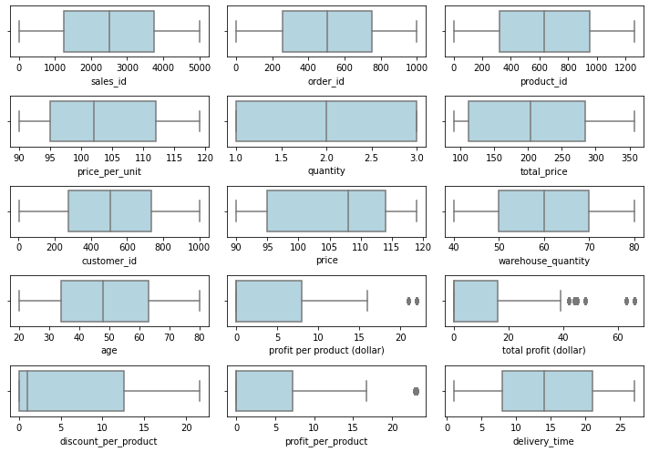

```python
plt.figure(figsize=(10,7))

for i in range(0, len(numerical.columns)):
    ax = plt.subplot(5,3,i+1)
    sns.boxplot(numerical[numerical.columns[i]], color='lightblue')
    plt.tight_layout()
```

*Boxplot visualisation shows outliers in the **'profit per product (dollar)', 'total profit (dollar)', and 'profit_per_product'** columns. I decide not to remove outliers data here because data detected as outliers are still reasonable and not invalid data, invalid means the data is corrupted, or incorrect. The outliers here occur in the data less frequently. Removing outliers here means drop all the non-zero entries, so column would be constant, less variable than it is in reality, and will lose a lot of valuable information, hence useless. Moreover, the infrequent data might happen again and may be very valuable in terms of the unique information they bring to the data. So there will be no cleaning of the ouliers data so that all the price profit values can be further analysed.*

## 3. Exploratory Data Analysis

```python
df.head()
```

|  | sales_id | order_id | product_id | price_per_unit | quantity | total_price | customer_id | order_date | delivery_date | product_type | product_name | size | colour | price | warehouse_quantity | description | gender | age | state | profit per product (dollar) | total profit (dollar) | discount_per_product | profit_per_product | season | delivery_time |
| --- | --- | --- | --- | --- | --- | --- | --- | --- | --- | --- | --- | --- | --- | --- | --- | --- | --- | --- | --- | --- | --- | --- | --- | --- | --- |
| 0 | 0 | 1 | 218 | 106 | 2 | 212 | 64 | 2021-08-30 | 2021-09-24 | Shirt | Chambray | L | orange | 105 | 44 | A orange coloured, L sized, Chambray Shirt | Genderfluid | 75 | South Australia | 1 | 2 | 0.00 | 0.95 | Winter | 25 |
| 1 | 1 | 1 | 481 | 118 | 1 | 118 | 64 | 2021-08-30 | 2021-09-24 | Jacket | Puffer | S | indigo | 110 | 62 | A indigo coloured, S sized, Puffer Jacket | Genderfluid | 75 | South Australia | 8 | 8 | 0.00 | 7.27 | Winter | 25 |
| 2 | 2 | 1 | 2 | 96 | 3 | 288 | 64 | 2021-08-30 | 2021-09-24 | Shirt | Oxford Cloth | M | red | 114 | 54 | A red coloured, M sized, Oxford Cloth Shirt | Genderfluid | 75 | South Australia | 0 | 0 | 15.79 | 0.00 | Winter | 25 |
| 3 | 3 | 1 | 1002 | 106 | 2 | 212 | 64 | 2021-08-30 | 2021-09-24 | Trousers | Wool | M | blue | 111 | 52 | A blue coloured, M sized, Wool Trousers | Genderfluid | 75 | South Australia | 0 | 0 | 4.50 | 0.00 | Winter | 25 |
| 4 | 4 | 1 | 691 | 113 | 3 | 339 | 64 | 2021-08-30 | 2021-09-24 | Jacket | Parka | S | indigo | 119 | 53 | A indigo coloured, S sized, Parka Jacket | Genderfluid | 75 | South Australia | 0 | 0 | 5.04 | 0.00 | Winter | 25 |

### 3.1 Descriptive Statistics

```python
numerical.describe()
```

|  | sales_id | order_id | product_id | price_per_unit | quantity | total_price | customer_id | price | warehouse_quantity | age | profit per product (dollar) | total profit (dollar) | discount_per_product | profit_per_product | delivery_time |
| --- | --- | --- | --- | --- | --- | --- | --- | --- | --- | --- | --- | --- | --- | --- | --- |
| count | 5000.000000 | 5000.000000 | 5000.000000 | 5000.000000 | 5000.00000 | 5000.000000 | 5000.000000 | 5000.000000 | 5000.000000 | 5000.000000 | 5000.000000 | 5000.000000 | 5000.000000 | 5000.000000 | 5000.000000 |
| mean | 2499.500000 | 503.038200 | 634.053200 | 103.501600 | 1.99240 | 206.360000 | 504.563000 | 105.665400 | 60.083400 | 48.760400 | 4.982600 | 10.048200 | 6.268722 | 5.176032 | 13.990200 |
| std | 1443.520003 | 285.964418 | 363.255794 | 9.195004 | 0.80751 | 86.357457 | 276.504896 | 9.735564 | 11.682523 | 17.577519 | 7.160681 | 16.055698 | 7.670854 | 7.588702 | 7.665106 |
| min | 0.000000 | 1.000000 | 1.000000 | 90.000000 | 1.00000 | 90.000000 | 1.000000 | 90.000000 | 40.000000 | 20.000000 | 0.000000 | 0.000000 | 0.000000 | 0.000000 | 1.000000 |
| 25% | 1249.750000 | 258.000000 | 323.000000 | 95.000000 | 1.00000 | 112.000000 | 276.000000 | 95.000000 | 50.000000 | 34.000000 | 0.000000 | 0.000000 | 0.000000 | 0.000000 | 8.000000 |
| 50% | 2499.500000 | 504.500000 | 635.000000 | 102.000000 | 2.00000 | 204.000000 | 509.000000 | 108.000000 | 60.000000 | 48.000000 | 0.000000 | 0.000000 | 1.060000 | 0.000000 | 14.000000 |
| 75% | 3749.250000 | 749.000000 | 951.000000 | 112.000000 | 3.00000 | 285.000000 | 733.000000 | 114.000000 | 70.000000 | 63.000000 | 8.000000 | 16.000000 | 12.610000 | 7.270000 | 21.000000 |
| max | 4999.000000 | 999.000000 | 1259.000000 | 119.000000 | 3.00000 | 357.000000 | 1000.000000 | 119.000000 | 80.000000 | 80.000000 | 22.000000 | 66.000000 | 21.550000 | 23.160000 | 27.000000 |

```python
categorical.describe()
```

|  | order_date | delivery_date | product_type | product_name | size | colour | description | gender | state | season |
| --- | --- | --- | --- | --- | --- | --- | --- | --- | --- | --- |
| count | 5000 | 5000 | 5000 | 5000 | 5000 | 5000 | 5000 | 5000 | 5000 | 5000 |
| unique | 291 | 304 | 3 | 35 | 5 | 7 | 1233 | 8 | 8 | 4 |
| top | 2021-06-21 00:00:00 | 2021-03-28 00:00:00 | Trousers | Denim | M | blue | A orange coloured, L sized, Flannel Shirt | Female | South Australia | Winter |
| freq | 51 | 49 | 1683 | 273 | 1022 | 762 | 13 | 712 | 718 | 1573 |
| first | 2021-01-01 00:00:00 | 2021-01-03 00:00:00 | NaN | NaN | NaN | NaN | NaN | NaN | NaN | NaN |
| last | 2021-10-24 00:00:00 | 2021-11-20 00:00:00 | NaN | NaN | NaN | NaN | NaN | NaN | NaN | NaN |

### 3.2 Number of Sales per Month

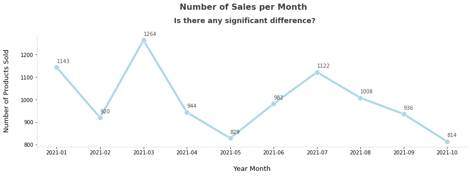

```python
# plot
plt.figure(figsize=(15,4))
df['year_month'] = df['order_date'].dt.strftime('%Y-%m')
data_qt = df.groupby(['year_month'], as_index=False)['quantity'].sum()
ax = sns.lineplot(x='year_month', y='quantity', marker='o', markersize=10, lw=4, color='lightblue', alpha=1, data=data_qt)

# data points
for x, y in zip(data_qt['year_month'], data_qt['quantity']):
    plt.text(x, y=y+20, s='{:.0f}'.format(y), alpha=.7)

# setting
sns.despine(top=True, right=True, left=False, bottom=False)
ax.spines['left'].set_color('lightgray')
ax.spines['bottom'].set_color('lightgray')
plt.xlabel('Year Month', fontsize=13, labelpad=20)
plt.ylabel('Number of Products Sold', fontsize=13, labelpad=20)
plt.title('Number of Sales per Month', fontweight='bold', fontsize=16, y=1.2, x=.48, alpha = .75)
plt.suptitle('Is there any significant difference?', fontweight='bold', fontsize = 14, y=1, x=.5, alpha = .75);
```

#### 3.2.1 Percentage Change in Sales per Month

```
posx and posy should be finite values
posx and posy should be finite values
posx and posy should be finite values
```

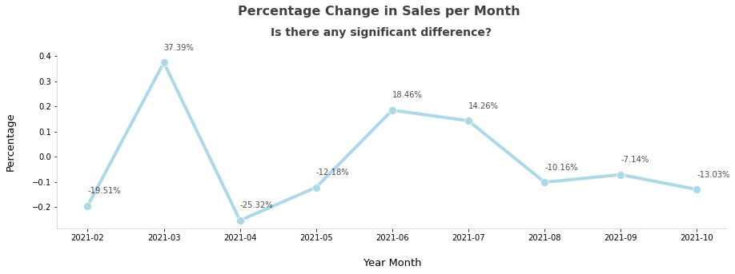

```python
data_pct_qt = data_qt.copy()
data_pct_qt['pct sales'] = data_pct_qt['quantity'].pct_change()

# plot
plt.figure(figsize=(15,4))
ax = sns.lineplot(x='year_month', y='pct sales', marker='o', markersize=10, lw=4, color='lightblue', alpha=1, data=data_pct_qt)

# data points
for x, y in zip(data_pct_qt['year_month'], data_pct_qt['pct sales']):
    plt.text(x, y+0.05, s='{:.2f}%'.format(y*100), alpha=.7)

# setting
sns.despine(top=True, right=True, left=False, bottom=False)
ax.spines['left'].set_color('lightgray')
ax.spines['bottom'].set_color('lightgray')
plt.xlabel('Year Month', fontsize=13, labelpad=20)
plt.ylabel('Percentage', fontsize=13, labelpad=20)
plt.title('Percentage Change in Sales per Month', fontweight='bold', fontsize=16, y=1.2, x=.48, alpha = .75)
plt.suptitle('Is there any significant difference?', fontweight='bold', fontsize = 14, y=1, x=.5, alpha = .75);
```

#### 3.2.2 Check for Each Product

```python
df['product_type'].value_counts()
```

```
Trousers    1683
Jacket      1676
Shirt       1641
Name: product_type, dtype: int64
```

*check for Trousers*

```python
data_tr = df[df['product_type'] == 'Trousers']
```

```python
data_tr['year_month'] = data_tr['order_date'].dt.strftime('%Y-%m')
data_pct_sales_tr = data_tr.groupby(['year_month'], as_index=False)['quantity'].sum()
data_pct_sales_tr['pct sales tr'] = data_pct_sales_tr['quantity'].pct_change();
```

*check for Jacket*

```python
data_jk = df[df['product_type'] == 'Jacket']
```

```python
data_jk['year_month'] = data_jk['order_date'].dt.strftime('%Y-%m')
data_pct_sales_jk = data_jk.groupby(['year_month'], as_index=False)['quantity'].sum()
data_pct_sales_jk['pct sales jk'] = data_pct_sales_jk['quantity'].pct_change()
```

*check for Shirt*

```python
data_sh = df[df['product_type'] == 'Shirt']
```

```python
data_sh['year_month'] = data_sh['order_date'].dt.strftime('%Y-%m')
data_pct_sales_sh = data_sh.groupby(['year_month'], as_index=False)['quantity'].sum()
data_pct_sales_sh['pct sales sh'] = data_pct_sales_sh['quantity'].pct_change()
```

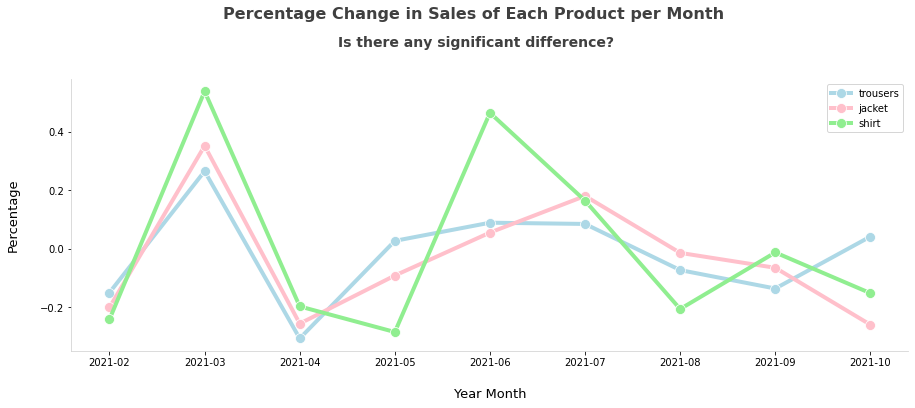

```python
fig = plt.figure(figsize=(15,5))

ax = fig.add_subplot(1, 1, 1)

# plot trousers
sns.lineplot(x='year_month', y='pct sales tr', marker='o', markersize=10, lw=4, color='lightblue', alpha=1, data=data_pct_sales_tr, label='trousers')

# data points
# for x, y in zip(data_pct_sales_tr['year_month'], data_pct_sales_tr['pct sales tr']):
#     plt.text(x, y+0.025, s='{:.2f}%'.format(y*100), alpha=.7, color='blue')


# plot jacket
sns.lineplot(x='year_month', y='pct sales jk', marker='o', markersize=10, lw=4, color='pink', alpha=1, data=data_pct_sales_jk, label='jacket')

# data points
# for x, y in zip(data_pct_sales_jk['year_month'], data_pct_sales_jk['pct sales jk']):
#     plt.text(x, y+0.025, s='{:.2f}%'.format(y*100), alpha=.7, color='red')


# plot shirt
sns.lineplot(x='year_month', y='pct sales sh', marker='o', markersize=10, lw=4, color='lightgreen', alpha=1, data=data_pct_sales_sh, label='shirt')

# data points
# for x, y in zip(data_pct_sales_sh['year_month'], data_pct_sales_sh['pct sales sh']):
#     plt.text(x, y+0.025, s='{:.2f}%'.format(y*100), alpha=.7, color='green')


# setting
sns.despine(top=True, right=True, left=False, bottom=False)
ax.spines['left'].set_color('lightgray')
ax.spines['bottom'].set_color('lightgray')
plt.xlabel('Year Month', fontsize=13, labelpad=20)
plt.ylabel('Percentage', fontsize=13, labelpad=20)
plt.title('Percentage Change in Sales of Each Product per Month', fontweight='bold', fontsize=16, y=1.2, x=.48, alpha = .75)
plt.suptitle('Is there any significant difference?', fontweight='bold', fontsize = 14, y=1, x=.5, alpha = .75)
plt.legend()
plt.show();
```

### 3.3 Total Profit per Month

```python
df['year_month'] = df['order_date'].dt.strftime('%Y-%m')
data_pf = df.groupby(['year_month'], as_index=False)['total profit (dollar)'].sum()
```

```
posx and posy should be finite values
posx and posy should be finite values
posx and posy should be finite values
```

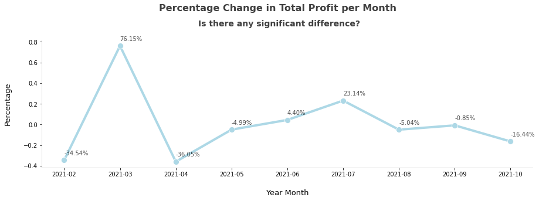

```python
data_pct_pf = data_pf.copy()
data_pct_pf['pct total profit'] = data_pct_pf['total profit (dollar)'].pct_change()

# plot
plt.figure(figsize=(15,4))
ax = sns.lineplot(x='year_month', y='pct total profit', marker='o', markersize=10, lw=4, color='lightblue', alpha=1, data=data_pct_pf)

# data points
for x, y in zip(data_pct_pf['year_month'], data_pct_pf['pct total profit']):
    plt.text(x, y+0.05, s='{:.2f}%'.format(y*100), alpha=.7)

# setting
sns.despine(top=True, right=True, left=False, bottom=False)
ax.spines['left'].set_color('lightgray')
ax.spines['bottom'].set_color('lightgray')
plt.xlabel('Year Month', fontsize=13, labelpad=20)
plt.ylabel('Percentage', fontsize=13, labelpad=20)
plt.title('Percentage Change in Total Profit per Month', fontweight='bold', fontsize=16, y=1.2, x=.48, alpha = .75)
plt.suptitle('Is there any significant difference?', fontweight='bold', fontsize = 14, y=1, x=.5, alpha = .75);
```

### 3.4 Number of Sales Per Product

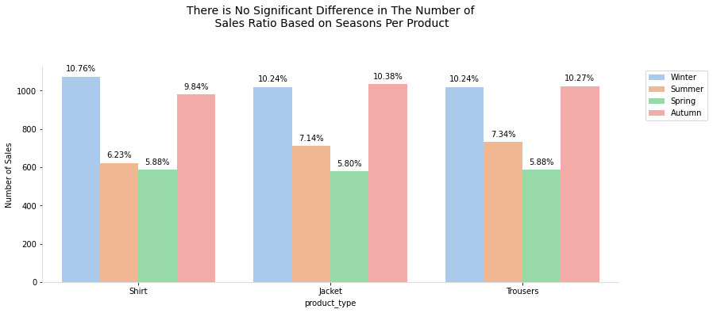

```python
plt.figure(figsize=(13,5))

# plot
ax = sns.barplot(x="product_type", y="quantity", data=df, estimator=sum, hue='season', palette="pastel", ci=None)
sns.despine(top=True, right=True, left=False, bottom=False);
ax.spines['left'].set_color('lightgray');
ax.spines['bottom'].set_color('lightgray');

# data points
tampung = []
for x in ax.patches:
    tampung.append(x.get_height())

for x in ax.patches:
#     ax.annotate(f'{x.get_height():0.0f}', (x.get_x() + x.get_width() / 2., x.get_height()), ha = 'center', va = 'center', xytext = (0, 10), textcoords = 'offset points')
    ax.annotate(f'{100 * x.get_height() / sum(tampung):0.2f}%', (x.get_x() + x.get_width() / 2, x.get_height()), ha = 'center', va = 'center', xytext = (0, 10), textcoords = 'offset points')

# settings
ax.set_ylabel('Number of Sales');
ax.set_title('There is No Significant Difference in The Number of\n Sales Ratio Based on Seasons Per Product', fontsize = 14, pad = 50)
plt.legend(bbox_to_anchor=(1.04,1), loc='upper left');
```

- *All products have a high number of sales in Winter and Autumn*

### 3.5 Business Problem

*Here includes descriptive, diagnostic, predictive, and prescriptive analytics.*

*1.Sales experienced a significant increase in the early Autumn and Winter seasons, then decreased significantly in the following month.*

- Is there a correlation between the number of product sales and the season?
- Is there certain product that affects sales in certain seasons?
- How to reduce the decline in product sales (up to 25.32%) in all seasons?
1. What are the product sales predictions in November and December?
2. How to increase product sales if it is proven that there is a decline in sales in 2021?
3. What factors affect the decline in sales?

## 4. Sales Forecasting

```python
 !pip install pmdarima
```

```
     |████████████████████████████████| 1.4 MB 5.2 MB/s
     |████████████████████████████████| 9.8 MB 42.3 MB/s
  Attempting uninstall: statsmodels
    Found existing installation: statsmodels 0.10.2
    Uninstalling statsmodels-0.10.2:
      Successfully uninstalled statsmodels-0.10.2
```

```python
# daily sales

df_dl = df.groupby(['order_date','season','product_type'], as_index=False)['quantity'].sum()
df_dl['order_date'] = df['order_date'].dt.date

# pivot
df_dl_p = (
    df_dl
    .pivot_table(columns='product_type',index=['order_date','season'],aggfunc=np.sum,margins=True)['quantity']
)

# Formatting.
df_dl_p.reset_index(inplace=True)
df_dl_p.columns.name = None

df_dl_p.columns = ['order_date','season','jacket','shirt','trousers','total_sales']
df_dl_p
```

|  | order_date | season | jacket | shirt | trousers | total_sales |
| --- | --- | --- | --- | --- | --- | --- |
| 0 | 2021-01-01 | Summer | 35.0 | 31.0 | 29.0 | 95 |
| 1 | 2021-01-03 | Autumn | 5.0 | 11.0 | 8.0 | 24 |
| 2 | 2021-01-05 | Spring | 6.0 | 29.0 | 22.0 | 57 |
| 3 | 2021-01-07 | Autumn | 13.0 | 11.0 | 9.0 | 33 |
| 4 | 2021-01-08 | Winter | 10.0 | 27.0 | 10.0 | 47 |
| ... | ... | ... | ... | ... | ... | ... |
| 156 | 2021-10-18 | Winter | 33.0 | 14.0 | 15.0 | 62 |
| 157 | 2021-10-21 | Spring | 30.0 | 28.0 | 18.0 | 76 |
| 158 | 2021-10-22 | Autumn | 30.0 | 28.0 | 20.0 | 78 |
| 159 | 2021-10-22 | Winter | 6.0 | NaN | 4.0 | 10 |
| 160 | All |  | 3343.0 | 3259.0 | 3360.0 | 9962 |

161 rows × 6 columns

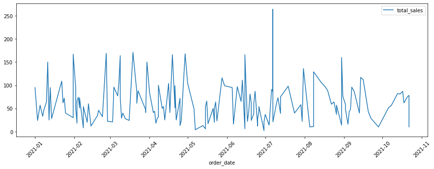

```python
df_dl_p[:-1].plot(x='order_date', y='total_sales', figsize=(15,5))
plt.xticks(rotation=45)
plt.show()
```

```python
# monthly sales

df['year_month'] = pd.to_datetime(df['year_month']).dt.date
df_tm = df.groupby(['year_month','season','product_type'], as_index=False)['quantity'].sum()

# pivot
df_tm_p = (
    df_tm
    .pivot_table(columns='product_type',index=['year_month','season'],aggfunc=np.sum,margins=True)['quantity']
)

# Formatting.
df_tm_p.reset_index(inplace=True)
df_tm_p.columns.name = None

df_tm_p.columns = ['year_month','season','jacket','shirt','trousers','total_sales']
df_tm_p
```

|  | year_month | season | jacket | shirt | trousers | total_sales |
| --- | --- | --- | --- | --- | --- | --- |
| 0 | 2021-01-01 | Summer | 395 | 353 | 395 | 1143 |
| 1 | 2021-02-01 | Summer | 316 | 268 | 336 | 920 |
| 2 | 2021-03-01 | Autumn | 427 | 412 | 425 | 1264 |
| 3 | 2021-04-01 | Autumn | 318 | 331 | 295 | 944 |
| 4 | 2021-05-01 | Autumn | 289 | 237 | 303 | 829 |
| 5 | 2021-06-01 | Winter | 305 | 347 | 330 | 982 |
| 6 | 2021-07-01 | Winter | 360 | 404 | 358 | 1122 |
| 7 | 2021-08-01 | Winter | 355 | 321 | 332 | 1008 |
| 8 | 2021-09-01 | Spring | 332 | 317 | 287 | 936 |
| 9 | 2021-10-01 | Spring | 246 | 269 | 299 | 814 |
| 10 | All |  | 3343 | 3259 | 3360 | 9962 |

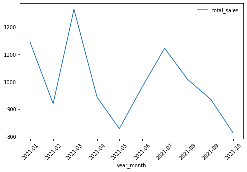

```python
df_tm_p[:-1].plot(x='year_month', y='total_sales', figsize=(8,5))
plt.xticks(rotation=45)
plt.show()
```

### Dickey-Fuller Test

```python
#applying dickey-fuller test
from statsmodels.tsa.stattools import adfuller

#creating a function for values
def adf_test(dataset):
  dftest = adfuller(dataset, autolag = 'AIC')
  print("1. ADF : ",dftest[0])
  print("2. P-Value : ", dftest[1])
  print("3. Num Of Lags : ", dftest[2])
  print("4. Num Of Observations Used For ADF Regression and Critical Values Calculation :", dftest[3])
  print("5. Critical Values :")
  for key, val in dftest[4].items():
      print("\t",key, ": ", val)

  if dftest[1] <= 0.05:
     print ("time series is stationary")
  else:
      print("time series is non-stationary")

#printing for total_sales
adf_test(df_tm_p[:-1]['total_sales'])
```

```
1. ADF :  -29.25278641636381
2. P-Value :  0.0
3. Num Of Lags :  3
4. Num Of Observations Used For ADF Regression and Critical Values Calculation : 6
5. Critical Values :
	 1% :  -5.354256481481482
	 5% :  -3.6462381481481483
	 10% :  -2.901197777777778
time series is stationary
```

### 4.1.Arma

#### 4.1.1 Splitting Data

```python
df_f = df_tm_p[:-1]

train = df_f[df_f['year_month'] <= pd.to_datetime('2021-06', format='%Y-%m')]
test = df_f[df_f['year_month'] >= pd.to_datetime('2021-06', format='%Y-%m')]

# plot
plt.figure(figsize=(10,5))
plt.plot( train['year_month'], train['total_sales'], color = "black", label="train")
plt.plot(test['year_month'], test['total_sales'], color = "red", label="test")
plt.title("Train/Test split for Sales Data")
plt.ylabel("Sales Number")
plt.xlabel('Month')
plt.xticks(rotation=45)
plt.legend()
plt.show()
```

[output not shown]

#### 4.1.2 Train Model

```python
month_predicted = [*range(5, 13, 1)]
```

[output not shown]

```
 This problem is unconstrained.
```

[output not shown]

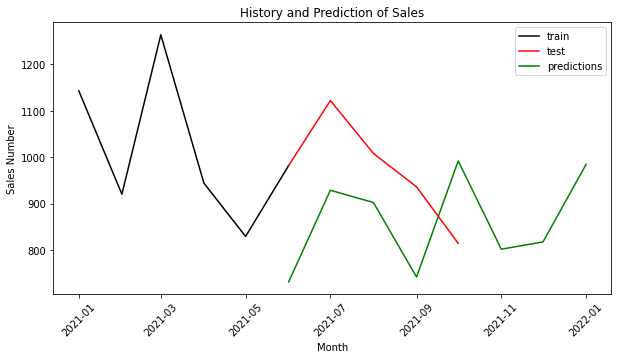

```python
from statsmodels.tsa.statespace.sarimax import SARIMAX

y = train['total_sales']

ARMAmodel = SARIMAX(y, order = (3,0,1))
ARMAmodel = ARMAmodel.fit()

# prediction
y_pred = ARMAmodel.get_forecast(len(month_predicted))
y_pred_df = y_pred.conf_int(alpha = 0.05)
y_pred_df["predictions"] = ARMAmodel.predict(end = 13)
y_pred_df.index = month_predicted
y_pred_out = y_pred_df["predictions"]

# modif month
y_pred_df['year_month'] = test['year_month']
# d = pd.date_range(start='11/1/2021', end='1/1/2022', freq='MS')
# y_pred_df['year_month'] = d
y_pred_df['year_month'][10] = pd.to_datetime('2021-11', format='%Y-%m')
y_pred_df['year_month'][11] = pd.to_datetime('2021-12', format='%Y-%m')
y_pred_df['year_month'][12] = pd.to_datetime('2022-01', format='%Y-%m')

# plot
plt.figure(figsize=(10,5))
plt.plot( train['year_month'], train['total_sales'], color = "black", label="train")
plt.plot(test['year_month'], test['total_sales'], color = "red", label="test")
plt.plot(y_pred_df['year_month'], y_pred_df['predictions'], color='green', label = 'predictions')
plt.title("History and Prediction of Sales")
plt.ylabel("Sales Number")
plt.xlabel('Month')
plt.xticks(rotation=45)
plt.legend()
plt.show()
```

#### 4.1.3 Model Evaluation

```python
from math import sqrt
from sklearn.metrics import mean_squared_error

rms = sqrt(mean_squared_error(test['total_sales'],y_pred_df['predictions'][0:5]))
print("RMSE: ", rms)
```

```
RMSE:  190.3138164370162
```

### 4.2 Arima with auto_arima

#### 4.2.1 Splitting Data

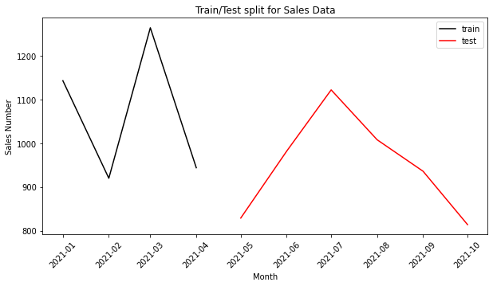

```python
df_f = df_tm_p[:-1]

train = df_f[df_f['year_month'] < pd.to_datetime('2021-05', format='%Y-%m')]
test = df_f[df_f['year_month'] >= pd.to_datetime('2021-05', format='%Y-%m')]

# plot
plt.figure(figsize=(10,5))
plt.plot( train['year_month'], train['total_sales'], color = "black", label="train")
plt.plot(test['year_month'], test['total_sales'], color = "red", label="test")
plt.title("Train/Test split for Sales Data")
plt.ylabel("Sales Number")
plt.xlabel('Month')
plt.xticks(rotation=45)
plt.legend()
plt.show()
```

#### 4.2.2 Train Model

```python
import  scipy.signal.signaltools

def _centered(arr, newsize):
    # Return the center newsize portion of the array.
    newsize = np.asarray(newsize)
    currsize = np.array(arr.shape)
    startind = (currsize - newsize) // 2
    endind = startind + newsize
    myslice = [slice(startind[k], endind[k]) for k in range(len(endind))]
    return arr[tuple(myslice)]

scipy.signal.signaltools._centered = _centered
```

```python
month_predicted = [*range(4, 13, 1)]
```

```
Performing stepwise search to minimize aic
 ARIMA(1,0,1)(0,0,0)[0] intercept   : AIC=nan, Time=0.08 sec
 ARIMA(0,0,0)(0,0,0)[0] intercept   : AIC=55.031, Time=0.01 sec
 ARIMA(1,0,0)(0,0,0)[0] intercept   : AIC=51.509, Time=0.06 sec
 ARIMA(0,0,1)(0,0,0)[0] intercept   : AIC=nan, Time=0.04 sec
 ARIMA(0,0,0)(0,0,0)[0]             : AIC=69.209, Time=0.00 sec
 ARIMA(1,0,1)(0,0,0)[0]             : AIC=nan, Time=0.06 sec

Best model:  ARIMA(1,0,0)(0,0,0)[0] intercept
Total fit time: 0.288 seconds
```

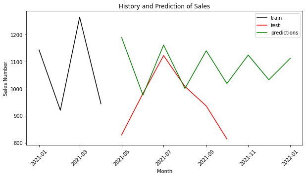

```python
from pmdarima.arima import auto_arima

y = train['total_sales']

model = auto_arima(y, trace=True, error_action='ignore', suppress_warnings=True)
model.fit(y)

# prediction
forecast = model.predict(n_periods=len(month_predicted))
forecast = pd.DataFrame(forecast,index = month_predicted,columns=['predictions'])
forecast.index = month_predicted
forecast_out = forecast['predictions']

# modif month
forecast['year_month'] = test['year_month']
forecast['year_month'][10] = pd.to_datetime('2021-11', format='%Y-%m')
forecast['year_month'][11] = pd.to_datetime('2021-12', format='%Y-%m')
forecast['year_month'][12] = pd.to_datetime('2022-01', format='%Y-%m')

# plot
plt.figure(figsize=(10,5))
plt.plot( train['year_month'], train['total_sales'], color = "black", label="train")
plt.plot(test['year_month'], test['total_sales'], color = "red", label="test")
plt.plot(forecast['year_month'], forecast['predictions'], color='green', label = 'predictions')
plt.title("History and Prediction of Sales")
plt.ylabel("Sales Number")
plt.xlabel('Month')
plt.xticks(rotation=45)
plt.legend()
plt.show()
```

#### 4.2.3 Model Evaluation

```python
from math import sqrt
from sklearn.metrics import mean_squared_error

rms = sqrt(mean_squared_error(test['total_sales'],forecast['predictions'][0:6]))
print("RMSE: ", rms)
```

```
RMSE:  189.15403589685783
```

### 4.3 Arima with best fit AIC -pdq/s by grid search

#### 4.3.1 Splitting Data

```python
df_f = df_tm_p[:-1]

train = df_f[df_f['year_month'] <= pd.to_datetime('2021-06', format='%Y-%m')]
test = df_f[df_f['year_month'] >= pd.to_datetime('2021-06', format='%Y-%m')]

# plot
plt.figure(figsize=(10,5))
plt.plot( train['year_month'], train['total_sales'], color = "black", label="train")
plt.plot(test['year_month'], test['total_sales'], color = "red", label="test")
plt.title("Train/Test split for Sales Data")
plt.ylabel("Sales Number")
plt.xlabel('Month')
plt.xticks(rotation=45)
plt.legend()
plt.show()
```

[output not shown]

#### 4.3.2 Train Model

```python
month_predicted = [*range(5, 10, 1)]
```

```
 This problem is unconstrained.
 This problem is unconstrained.
```

[output not shown]

[output cut: 159 more lines]

[output not shown]

```
 This problem is unconstrained.
 This problem is unconstrained.
 This problem is unconstrained.
 This problem is unconstrained.
 This problem is unconstrained.
 This problem is unconstrained.
```

[output not shown]

[output cut: 44 more lines]

[output not shown]

[output not shown]

[output cut: 28 more lines]

[output not shown]

```
 This problem is unconstrained.
 This problem is unconstrained.
```

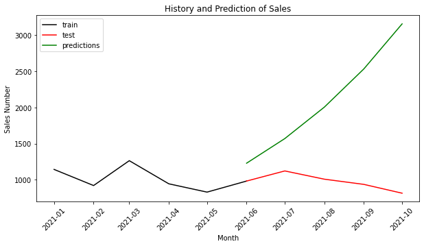

```python
from statsmodels.tsa.arima_model import ARIMA
import itertools

y = train['total_sales'].astype('float32')

# Grid Search
p = d = q = range(0,3) # p, d, and q can be either 0, 1, or 2
pdq = list(itertools.product(p,d,q)) # gets all possible combinations of p, d, and q
combs = {} # stores aic and order pairs
aics = [] # stores aics

# Grid Search continued
for combination in pdq:
    try:
        model = ARIMA(y, order=combination) # create all possible models
        model = model.fit()
        combs.update({model.aic : combination}) # store combinations
        aics.append(model.aic)
    except:
        continue

best_aic = min(aics)

# Model Creation
model = ARIMA(y, order=combs[best_aic])
model = model.fit()

# prediction
y_pred = model.forecast(len(month_predicted),alpha =0.05)[0]
y_pred_df = pd.DataFrame(y_pred)
y_pred_df.columns = ['predictions']
y_pred_df = y_pred_df.set_index([pd.Index(month_predicted)])

# modif month
y_pred_df['year_month'] = test['year_month']
y_pred_df['year_month'][10] = pd.to_datetime('2021-11', format='%Y-%m')
y_pred_df['year_month'][11] = pd.to_datetime('2021-12', format='%Y-%m')
y_pred_df['year_month'][12] = pd.to_datetime('2022-01', format='%Y-%m')

# plot
plt.figure(figsize=(10,5))
plt.plot( train['year_month'], train['total_sales'], color = "black", label="train")
plt.plot(test['year_month'], test['total_sales'], color = "red", label="test")
plt.plot(y_pred_df['year_month'], y_pred_df['predictions'], color='green', label = 'predictions')
plt.title("History and Prediction of Sales")
plt.ylabel("Sales Number")
plt.xlabel('Month')
plt.xticks(rotation=45)
plt.legend()
plt.show()
```

#### 4.3.3 Model Evaluation

```python
from math import sqrt
from sklearn.metrics import mean_squared_error

rms = sqrt(mean_squared_error(test['total_sales'],y_pred_df['predictions'][0:5]))
print("RMSE: ", rms)
```

```
RMSE:  1363.7430109811746
```

### 4.4 Arima

#### 4.4.1 Splitting Data

```python
df_f = df_tm_p[:-1]

train = df_f[df_f['year_month'] <= pd.to_datetime('2021-06', format='%Y-%m')]
test = df_f[df_f['year_month'] >= pd.to_datetime('2021-06', format='%Y-%m')]

# plot
plt.figure(figsize=(10,5))
plt.plot( train['year_month'], train['total_sales'], color = "black", label="train")
plt.plot(test['year_month'], test['total_sales'], color = "red", label="test")
plt.title("Train/Test split for Sales Data")
plt.ylabel("Sales Number")
plt.xlabel('Month')
plt.xticks(rotation=45)
plt.legend()
plt.show()
```

[output not shown]

#### 4.4.2 Train Model

```python
month_predicted = [*range(5, 13, 1)]
```

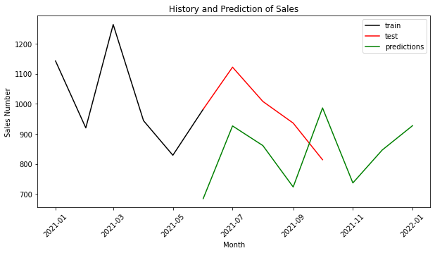

```python
from statsmodels.tsa.arima.model import ARIMA

y = train['total_sales']

ARIMAmodel = ARIMA(y, order = (2, 1, 2))
ARIMAmodel = ARIMAmodel.fit()

# prediction
y_pred = ARIMAmodel.get_forecast(len(month_predicted))
y_pred_df = y_pred.conf_int(alpha = 0.05)
y_pred_df["predictions"] = ARIMAmodel.predict(end = 13)
y_pred_df.index = month_predicted
y_pred_out = y_pred_df["predictions"]

# modif month
y_pred_df['year_month'] = test['year_month']
y_pred_df['year_month'][10] = pd.to_datetime('2021-11', format='%Y-%m')
y_pred_df['year_month'][11] = pd.to_datetime('2021-12', format='%Y-%m')
y_pred_df['year_month'][12] = pd.to_datetime('2022-01', format='%Y-%m')

# plot
plt.figure(figsize=(10,5))
plt.plot( train['year_month'], train['total_sales'], color = "black", label="train")
plt.plot(test['year_month'], test['total_sales'], color = "red", label="test")
plt.plot(y_pred_df['year_month'], y_pred_df['predictions'], color='green', label = 'predictions')
plt.title("History and Prediction of Sales")
plt.ylabel("Sales Number")
plt.xlabel('Month')
plt.xticks(rotation=45)
plt.legend()
plt.show()
```

#### 4.4.3 Model Evaluation

```python
from math import sqrt
from sklearn.metrics import mean_squared_error

rms = sqrt(mean_squared_error(test['total_sales'],y_pred_df['predictions'][0:5]))
print("RMSE: ", rms)
```

```
RMSE:  211.2610475819172
```

### 4.5 Sarima with best fit AIC -pdq/s by grid search

#### 4.5.1 Splitting Data

```python
df_f = df_tm_p[:-1]

train = df_f[df_f['year_month'] <= pd.to_datetime('2021-06', format='%Y-%m')]
test = df_f[df_f['year_month'] >= pd.to_datetime('2021-06', format='%Y-%m')]

# plot
plt.figure(figsize=(10,5))
plt.plot( train['year_month'], train['total_sales'], color = "black", label="train")
plt.plot(test['year_month'], test['total_sales'], color = "red", label="test")
plt.title("Train/Test split for Sales Data")
plt.ylabel("Sales Number")
plt.xlabel('Month')
plt.xticks(rotation=45)
plt.legend()
plt.show()
```

[output not shown]

#### 4.5.2 Train Model

```python
month_predicted = [*range(5, 13, 1)]
```